# Vogt_Johnny_Unit3_Prelive

Johnny Vogt

2025-09-07

## Discussion 1: Bootstrap intervals

The power of the bootstrap is to provide good estimates of the standard errors for statistics that are not as easy to work with. In turn, they can be used to provide confidence intervals (CIs) where no theoretical formula exists otherwise.

From the videos, Dr. Turner provided a general framework for providing CI’s using the bootstrap procedure. For example to provide a bootstrap interval for the median, there are two main steps. The first is to write a function, such as the following, that will produce the statistic of interest of any given bootstrap sample:

```r
med.fun<-function(x,i){median(x[i])}
```

A. Compute the following lines of code using the generic data set provided. Briefly explain what is the role of $i$ in the previous function is.

“i” is the index vector. It acts as a way to help choose the “median” only from the dataset that its been given. so it would have to pick the median between 18 10 16 and 14

```r
generic.data<-c(18,10,16,14)
median(generic.data)
index<-c(4,3,1,3)
generic.data[index]
median(generic.data[index])
med.fun(generic.data,index)
```

[output not shown]

The second step is to compute the bootstrap sampling distribution using your statistic and compute the interval. The following example applies the bootstrap to a sample that is skewed right:

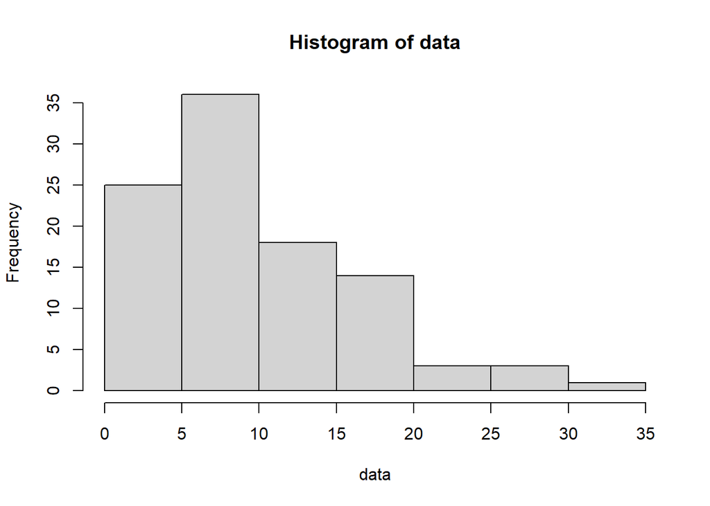

```r
library(boot)
data<-rgamma(100,2,scale=5)
hist(data)
```

```r
#mean(data)
#median(data)

#Performing Bootstap
med.boot<-boot(data,med.fun,R=2000)
#sd(med.boot$t) #SE from bootstrap

#Obtain CI's : Basic is "Empirical"
boot.ci(med.boot,conf=0.95,type=c("perc","basic","bca"))
```

```
## BOOTSTRAP CONFIDENCE INTERVAL CALCULATIONS
## Based on 2000 bootstrap replicates
##
## CALL :
## boot.ci(boot.out = med.boot, conf = 0.95, type = c("perc", "basic",
##     "bca"))
##
## Intervals :
## Level      Basic              Percentile            BCa
## 95%   ( 7.533, 10.005 )   ( 7.410,  9.883 )   ( 7.254,  9.824 )
## Calculations and Intervals on Original Scale
```

B. Suppose our main interest was the variability of the data set. Modify the previous code to make a confidence interval for the standard deviation and the interquartile range (IQR) of the data set. The functions you can use are `sd` and `IQR`

```r
sd.fun <- function(x, i) sd(x[i])
iqr.fun <- function(x, i) IQR(x[i])

sd.boot <- boot(data, sd.fun, R=2000)
iqr.boot <- boot(data, iqr.fun, R=2000)

boot.ci(sd.boot, conf=0.95, type=c("perc","basic","bca"))
```

```
## BOOTSTRAP CONFIDENCE INTERVAL CALCULATIONS
## Based on 2000 bootstrap replicates
##
## CALL :
## boot.ci(boot.out = sd.boot, conf = 0.95, type = c("perc", "basic",
##     "bca"))
##
## Intervals :
## Level      Basic              Percentile            BCa
## 95%   ( 5.423,  7.822 )   ( 5.389,  7.788 )   ( 5.681,  8.329 )
## Calculations and Intervals on Original Scale
```

```r
boot.ci(iqr.boot, conf=0.95, type=c("perc","basic","bca"))
```

```
## BOOTSTRAP CONFIDENCE INTERVAL CALCULATIONS
## Based on 2000 bootstrap replicates
##
## CALL :
## boot.ci(boot.out = iqr.boot, conf = 0.95, type = c("perc", "basic",
##     "bca"))
##
## Intervals :
## Level      Basic              Percentile            BCa
## 95%   ( 7.317, 12.143 )   ( 6.163, 10.988 )   ( 6.443, 11.403 )
## Calculations and Intervals on Original Scale
```

C. The next code provides the classic confidence interval for a population standard deviation assuming the data is normally distributed. Run the code, and compare the interval to your bootstrap interval. Which one is wider?

```r
n<-length(data)
Lower<-sqrt((n-1)*var(data)/qchisq(.05/2,n-1,lower.tail=F))
Upper<-sqrt((n-1)*var(data)/qchisq(.05/2,n-1,lower.tail=T))
c(Lower,Upper)
```

```
## [1] 5.799906 7.673752
```

## Discussion 2: Bootstrap for Regression

The videos discussed two approaches for the bootstrap in a linear regression setting. The first approach is to resample pairs, and the second approach is to resample residuals.

The following data set exhibits a situation where constant variance is not met.

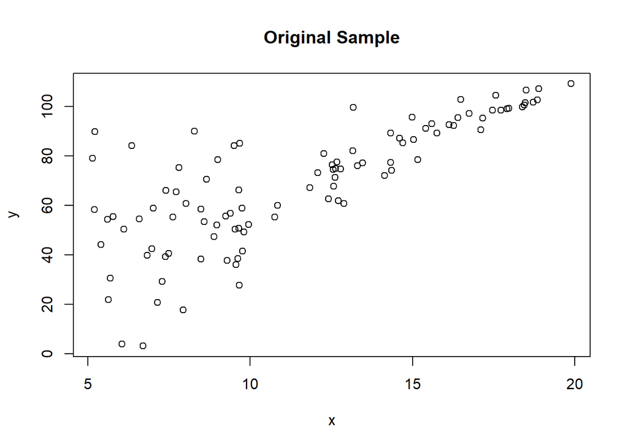

```r
set.seed(1234)
x<-runif(100,5,20)
sds<- (x-25)^2/15
y<-c()
for (i in 1:length(x)){
y[i]<-10+5*x[i]+rnorm(1,mean=0,sd=sds[i])
}

plot(x,y,main="Original Sample")
```

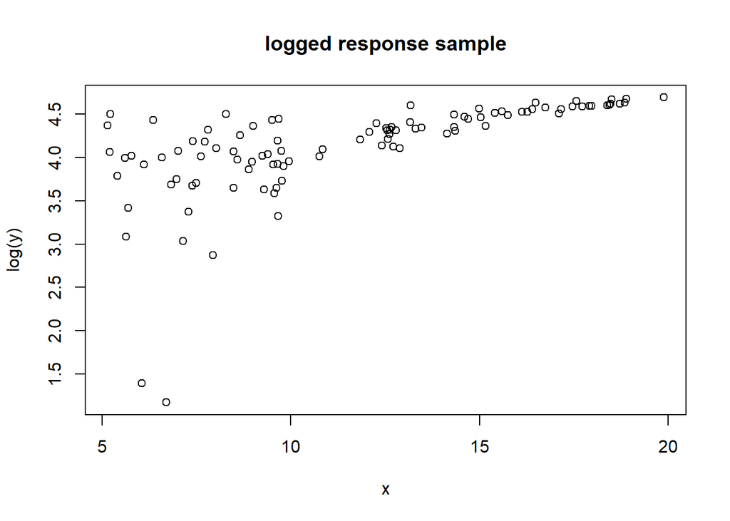

```r
plot(x,log(y),main="logged response sample")
```

1. Verify that log transforming the response variables doesn’t really work for this problem.

Yep, doesnt do much

2. The following code chunk provides three CIs for the slope and intercept. Compare the intervals to each other, and provide an explanation of which one you would prefer.

I would prefer using the Paired Bootstrap because it handles variances changing. Since this data set’s does not have a strong homoscedasticity (the data get narrower as x grows.)

```r
library(lmboot)
#PAIRED BOOTSTRAP
boot.p<-paired.boot(y~x,B=1000,seed=1234)
t(apply(boot.p$bootEstParam,2,quantile,probs=c(.025,.975)))
```

```
##                 2.5%    97.5%
## (Intercept) 4.263864 26.64593
## x           3.883905  5.38886
```

```r
#RESITUAL BOOTSTRAP
boot.res<-residual.boot(y~x,B=1000,seed=1234)
t(apply(boot.res$bootEstParam,2,quantile,probs=c(.025,.975)))
```

```
##                 2.5%     97.5%
## (Intercept) 6.910136 24.648401
## x           3.897229  5.375196
```

```r
#Traditional MLR
confint(lm(y~x))
```

```
##                2.5 %    97.5 %
## (Intercept) 6.605142 24.661904
## x           3.886191  5.355665
```

## Discussion 3: Boostrap Regression When Incorrectly Modeling the Trend

It is important to note that confidence intervals for regression coefficients are valid only when the assumptions for the errors are met. However, another important key to confidence intervals validity is that the trend being modeled is correctly specified.

The following code produces a data set that follows a quadratic trend with constant variance.

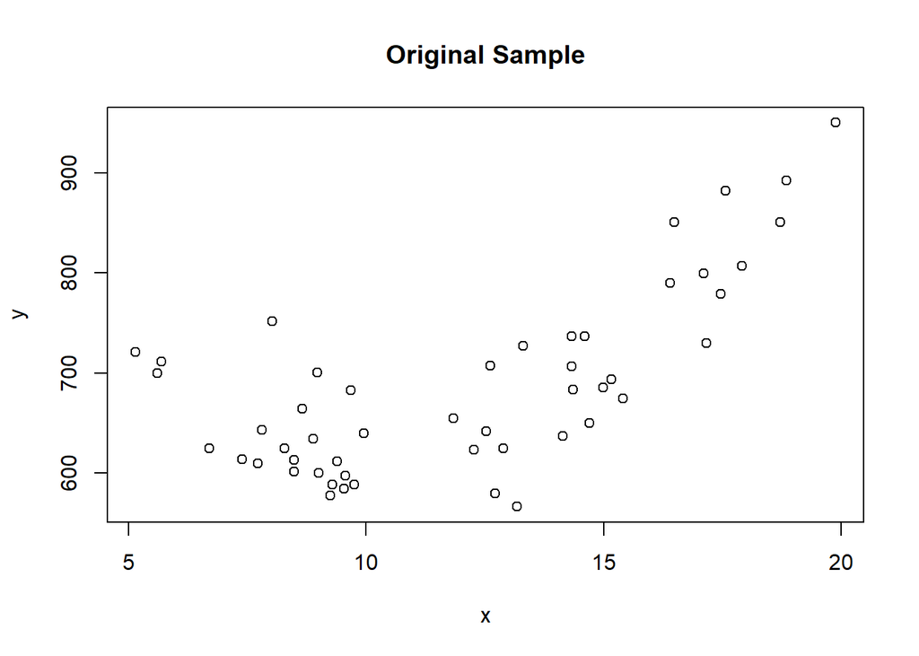

```r
set.seed(1234)
x<-runif(50,5,20)
y<-c()
for (i in 1:length(x)){
y[i]<-810-20*x[i]+4*(x[i]-8)^2+rnorm(1,mean=0,sd=40)
}

plot(x,y,main="Original Sample")
```

Like the previous exercise, we can compare the paired bootstrap interval to the traditional intervals when we correctly model the quadratic trend. Note that the intervals for all coefficients are pretty much in alignment.

I want you to investigate what happens if you incorrectly specify the model as only linear versus quadratic. Make note of any difference in the intervals between the bootstrap and classic intervals for intercept and slope. Which CI method would you prefer in this case if your goal was to provide an estimate of the linear slope?

```r
library(lmboot)

#PAIRED BOOTSTRAP
boot.p<-paired.boot(y~poly(x,2),B=1000,seed=1234)
t(apply(boot.p$bootEstParam,2,quantile,probs=c(.025,.975)))
```

```
##                 2.5%    97.5%
## (Intercept) 675.6235 698.6993
## poly(x, 2)1 349.9385 516.0560
## poly(x, 2)2 289.2160 435.2738
```

```r
#Traditional MLR
confint(lm(y~poly(x,2)))
```

```
##                2.5 %   97.5 %
## (Intercept) 674.3551 699.3721
## poly(x, 2)1 342.9952 519.8923
## poly(x, 2)2 274.9657 451.8629
```